# Introduction to R Practical session - All chapters in one

## 6.4 One variable: histogram

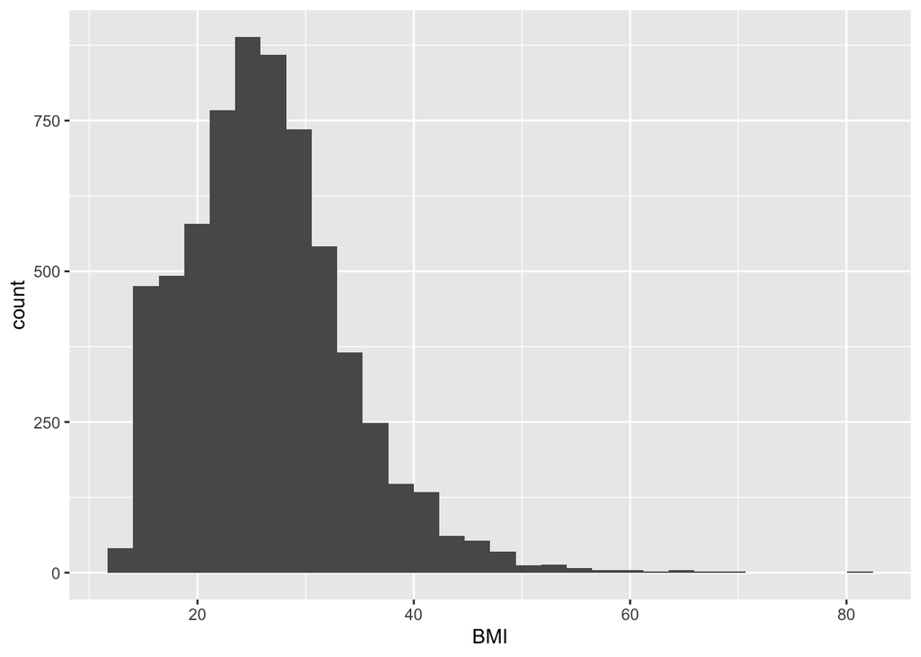

```r
ggplot(nh, aes(x = BMI)) +
  geom_histogram(bins = 30)
```

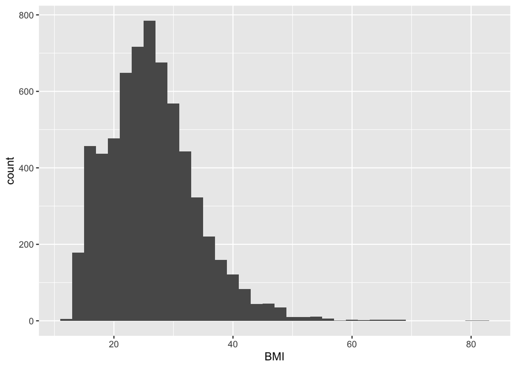

```r
ggplot(nh, aes(x = BMI)) +
  geom_histogram(binwidth = 2)
```

Does the shape change?

What alternatives to the simple histogram do you know?

Density plots, ridge plots, rainfall plots, violin plots, sina plot…

## 6.5 Two variables: scatter plot

In this case, two continuous variables

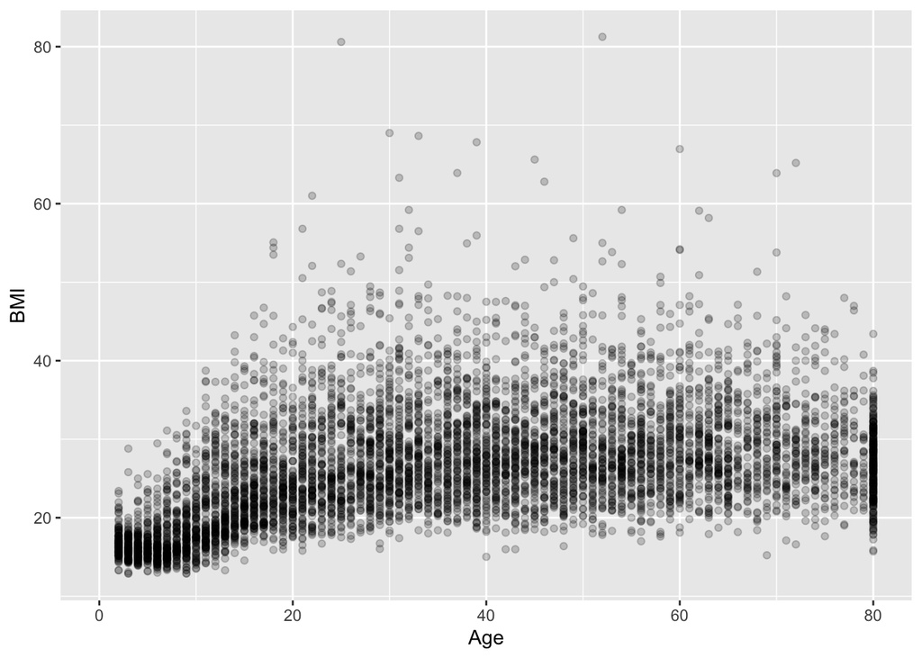

```r
ggplot(nh, aes(x = Age, y = BMI)) +
  geom_point(alpha = 0.2)
```

Why am I using alpha? Try without that!

## 6.6 Add more aesthetics

Look at the placement of the `colour`:

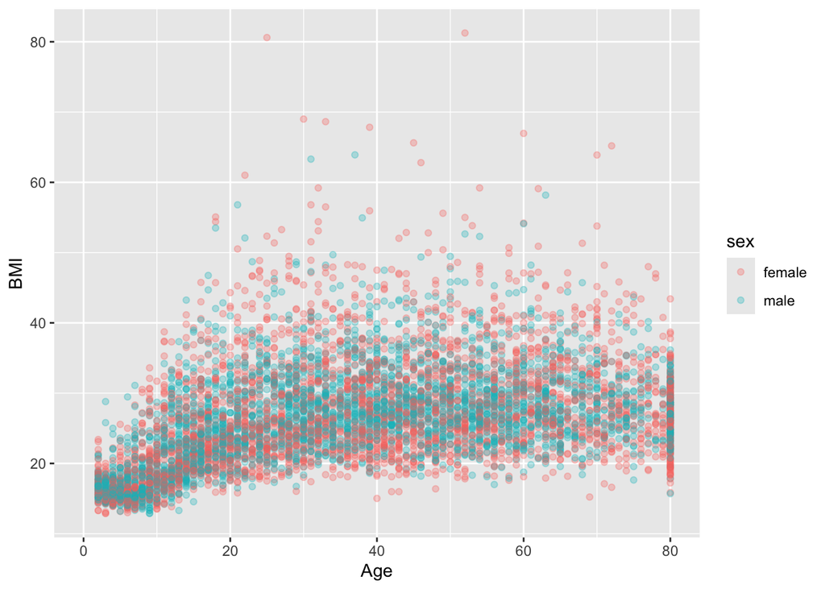

```r
ggplot(nh, aes(x = Age, y = BMI, colour = sex)) +
  geom_point(alpha = 0.3)
```

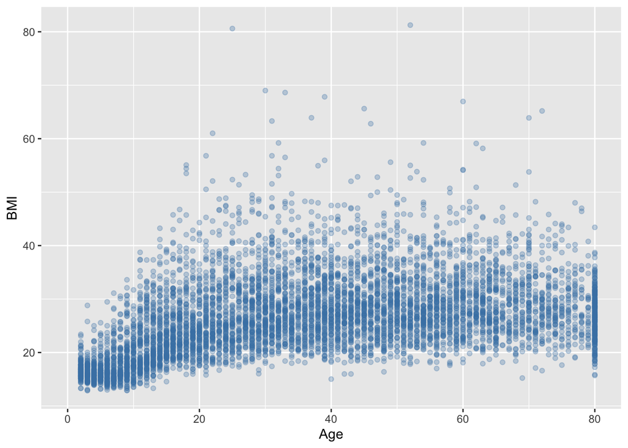

```r
ggplot(nh, aes(x = Age, y = BMI)) +
  geom_point(colour = "steelblue", alpha = 0.3)
```

What changed?

## 6.7 Facets: one panel per group

You’ll probably learn to love small multiples

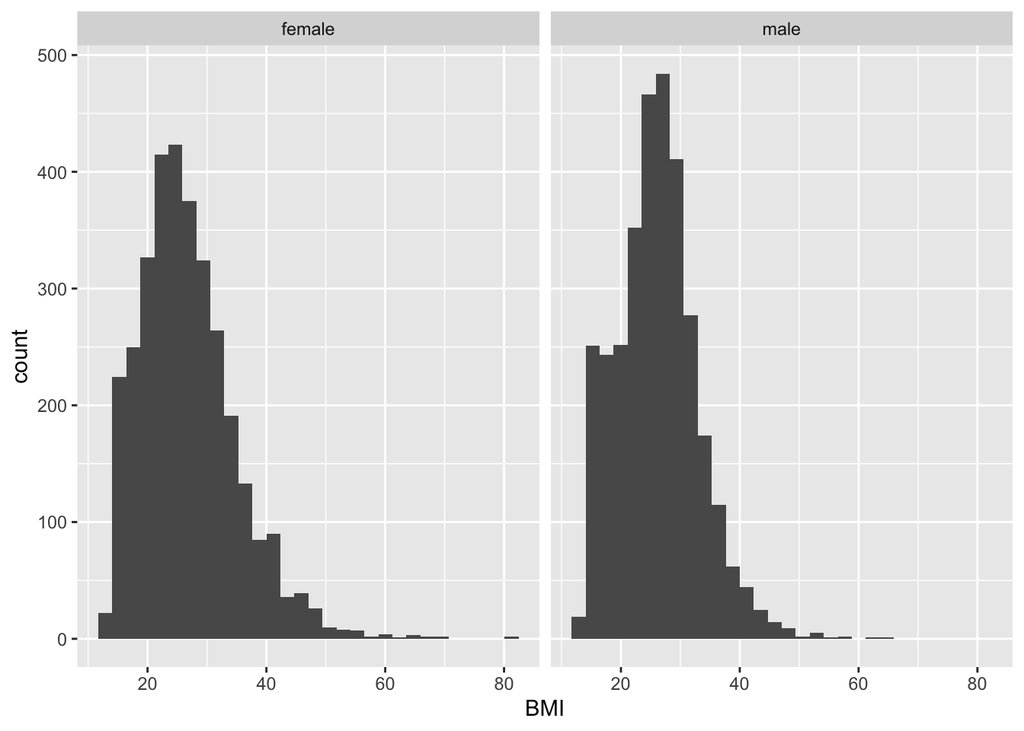

```r
ggplot(nh, aes(x = BMI)) +
  geom_histogram(bins = 30) +
  facet_wrap(~ sex)
```

## 6.8 Labels and themes

Controlling the aspect of the side dishes is important as well!

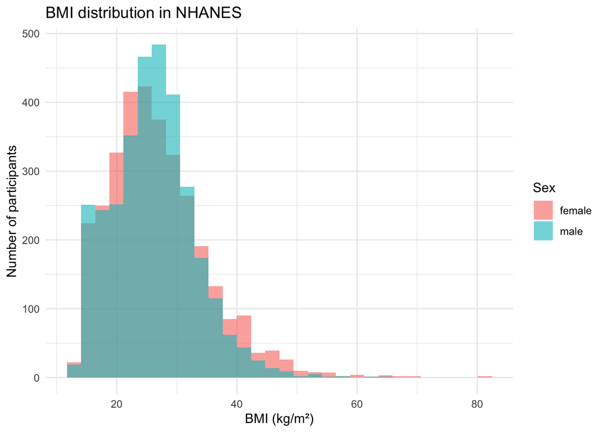

```r
ggplot(nh, aes(x = BMI, fill = sex)) +
  geom_histogram(bins = 30, alpha = 0.6, position = "identity") +
  labs(title = "BMI distribution in NHANES",
       x = "BMI (kg/m²)", y = "Number of participants",
       fill = "Sex") +
  theme_minimal()
```

Themes - an excellent and comfy way to change the looks of a plot. There are many collections of themes out there

## 6.9 Save that plot!

Each plot done via `ggplot` is returned as an object (and printed)

… and objects can be saved - how to do this efficiently?

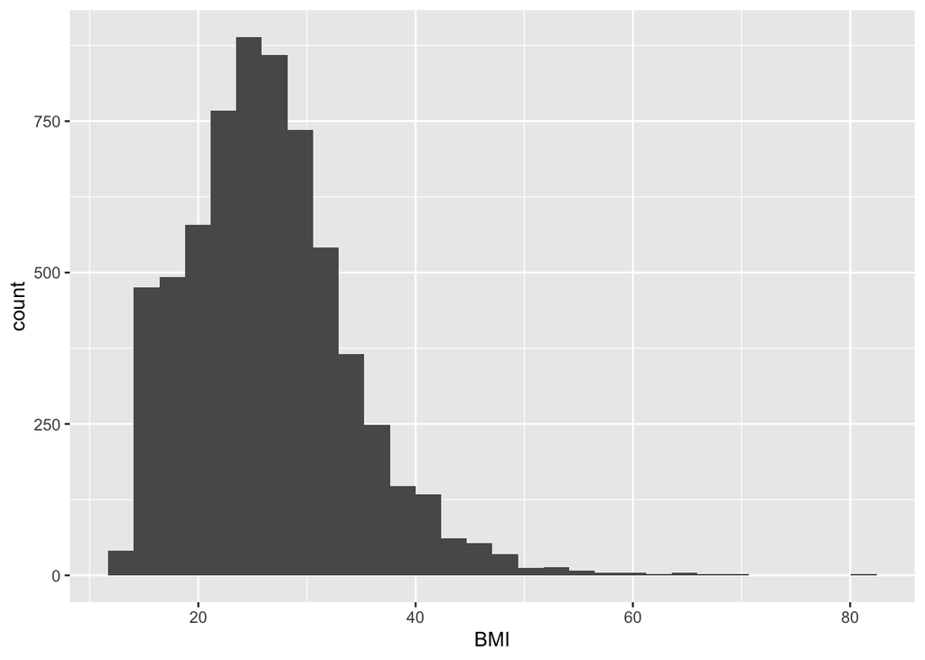

```r
p <- ggplot(nh, aes(x = BMI)) + geom_histogram(bins = 30)
p
```

```r
ggsave(p, filename = "bmi_hist.png", width = 6, height = 4, dpi = 300)
```

You can also use the RStudio interface, but I would heartily recommend *against* that.

## 6.10 From the previous chapters, now as plots

### 6.10.1 Chapter 3 flavour: distributions by group

Let’s have a look at the relationship between systolic blood pressure and smoking habits!

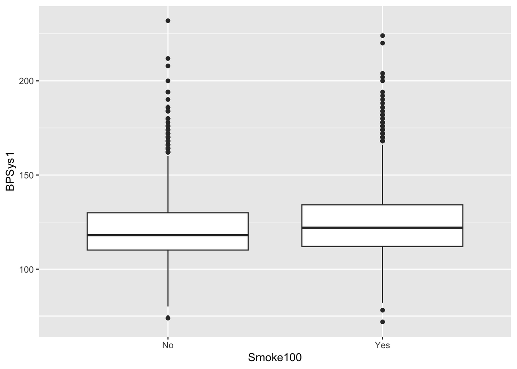

```r
nh |>
  drop_na(BPSys1, Smoke100) |>
  ggplot(aes(x = Smoke100, y = BPSys1)) +
  geom_boxplot()
```

Is this a fair comparison? What did we forget about age (chapter 5)?

## 6.11 Adults only, split by age group

We will use the facets here…

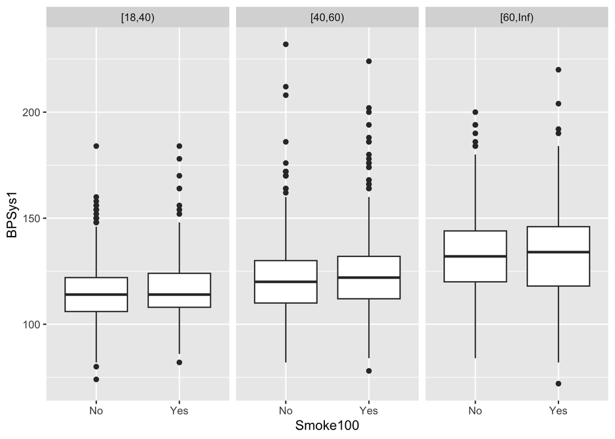

```r
nh |>
  filter(Age >= 18) |>
  drop_na(BPSys1, Smoke100) |>
  ggplot(aes(x = Smoke100, y = BPSys1)) +
  geom_boxplot() +
  facet_wrap(~ age_group)
```

Let’s try here some other `geom_`s!

`geom_jitter()`, `geom_violin()`, `ggforce::geom_sina` are just some of my favourites

### 6.11.1 Chapter 4: the guiding question

Remember that? “What is the prevalence of diabetes by BMI category, and how does it compare with HbA1c?”

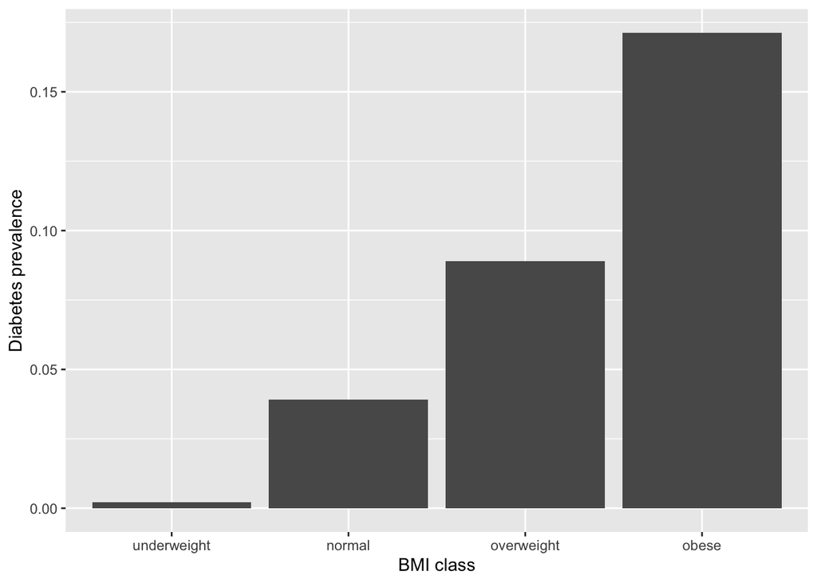

```r
nh |>
  drop_na(bmi_class, Diabetes) |>
  group_by(bmi_class) |>
  summarise(prevalence = mean(Diabetes == "Yes")) |>
  ggplot(aes(x = bmi_class, y = prevalence)) +
  geom_col() +
  labs(x = "BMI class", y = "Diabetes prevalence")
```

Now… by age group too

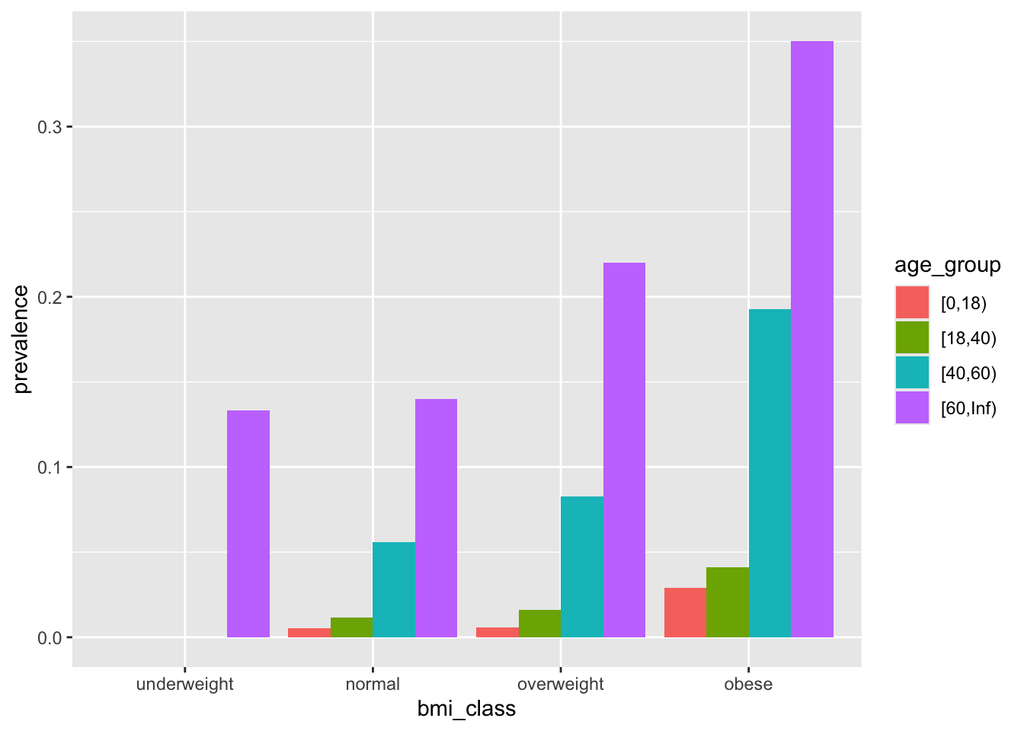

```r
nh |>
  drop_na(bmi_class, Diabetes, age_group) |>
  group_by(age_group, bmi_class) |>
  summarise(prevalence = mean(Diabetes == "Yes"), .groups = "drop") |>
  ggplot(aes(x = bmi_class, y = prevalence, fill = age_group)) +
  geom_col(position = "dodge")
```

## 6.12 HbA1c vs. diabetes status

The `geom_sina()` shows the density distribution AND individual observations

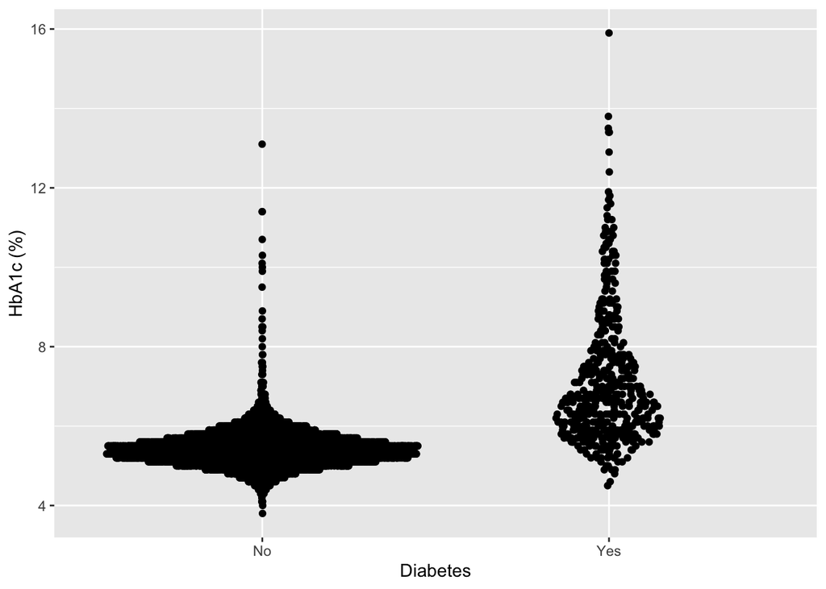

```r
nh |>
  drop_na(LBXGH, Diabetes) |>
  ggplot(aes(x = Diabetes, y = LBXGH)) +
  ggforce::geom_sina() +
  labs(y = "HbA1c (%)")
```

*Does this make sense?*

I know it sounds obvious and possibly naif - but don’t you ever forget to ask this question, every now and then. And especially after generating a result ^_^

### 6.12.1 Chapter 5: missing values

Let’s **see** the proportion of missing data

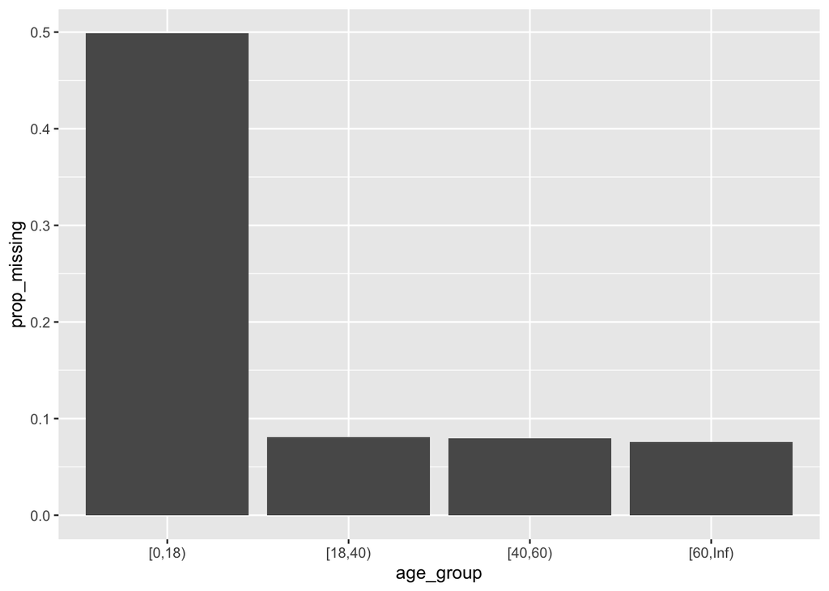

```r
nh |>
  mutate(bp_missing = is.na(BPSys1)) |>
  group_by(age_group) |>
  summarise(prop_missing = mean(bp_missing)) |>
  ggplot(aes(x = age_group, y = prop_missing)) +
  geom_col()
```

One plot vs one table - who wins?

Immediateness vs precision?

### 6.12.2 Chapter 5: the epi curve

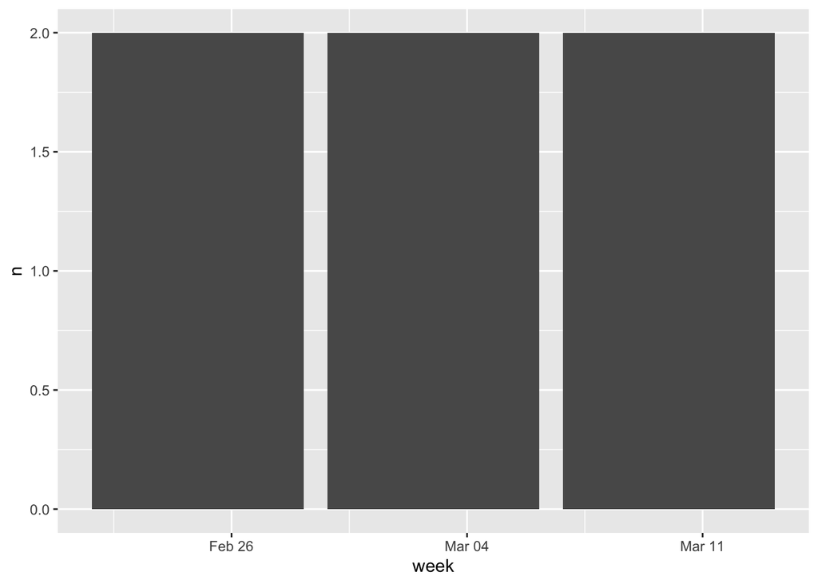

```r
library("lubridate")
linelist <- tibble(
  id    = 1:6,
  onset = ymd(c("2024-03-01", "2024-03-02", "2024-03-05",
                "2024-03-09", "2024-03-10", "2024-03-12"))
)

linelist |>
  mutate(week = floor_date(onset, "week")) |>
  count(week) |>
  ggplot(aes(x = week, y = n)) +
  geom_col()
```

## 6.13 Challenges

### 6.13.1 Challenge: make your insight!

Pick **two NHANES variables** and make a plot you would be happy to show a colleague:

- a sensible geom for the variable types
- a title and clear axis labels
- one extra aesthetic (colour or facet)
- **one sentence** under the plot saying what it shows

### 6.13.2 Challenge: improve it

- Reorder the levels of `Education` and plot it as a bar chart
- Add `geom_smooth()` to the scatter plot of `Age` vs `BMI`
- Change colours with `scale_fill_brewer()` or `scale_colour_viridis_d()`

I can only recommend to have a look at least once at this: https://apreshill.github.io/ohsu-biodatavis/slides.html

## 6.14 The `gapminder` dataset

[video not shown]

*Hans Rosling, TED 2006*

## 6.15 The `gapminder` data, in R

```r
library("gapminder")
glimpse(gapminder)
```

```
#> Rows: 1,704
#> Columns: 6
#> $ country   <fct> "Afghanistan", "Afghanistan", "Afghanistan", "Afghanistan", …
#> $ continent <fct> Asia, Asia, Asia, Asia, Asia, Asia, Asia, Asia, Asia, Asia, …
#> $ year      <int> 1952, 1957, 1962, 1967, 1972, 1977, 1982, 1987, 1992, 1997, …
#> $ lifeExp   <dbl> 28.801, 30.332, 31.997, 34.020, 36.088, 38.438, 39.854, 40.8…
#> $ pop       <int> 8425333, 9240934, 10267083, 11537966, 13079460, 14880372, 12…
#> $ gdpPercap <dbl> 779.4453, 820.8530, 853.1007, 836.1971, 739.9811, 786.1134, …
```

```r
gapminder |>
  filter(year == 2007) |>
  count(continent)
```

```
#> # A tibble: 5 × 2
#>   continent     n
#>   <fct>     <int>
#> 1 Africa       52
#> 2 Americas     25
#> 3 Asia         33
#> 4 Europe       30
#> 5 Oceania       2
```

## 6.16 One year, three variables

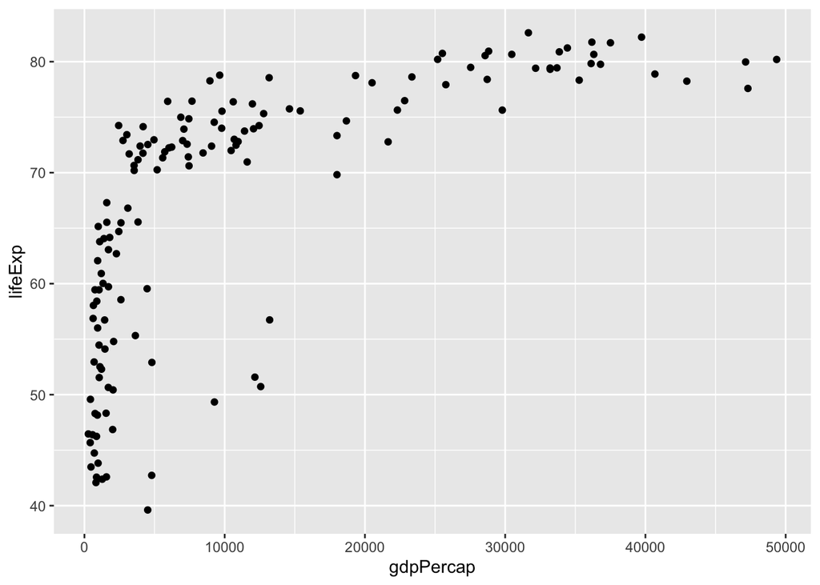

```r
gapminder |>
  filter(year == 2007) |>
  ggplot(aes(x = gdpPercap, y = lifeExp)) +
  geom_point()
```

## 6.17 Make it readable: log scale

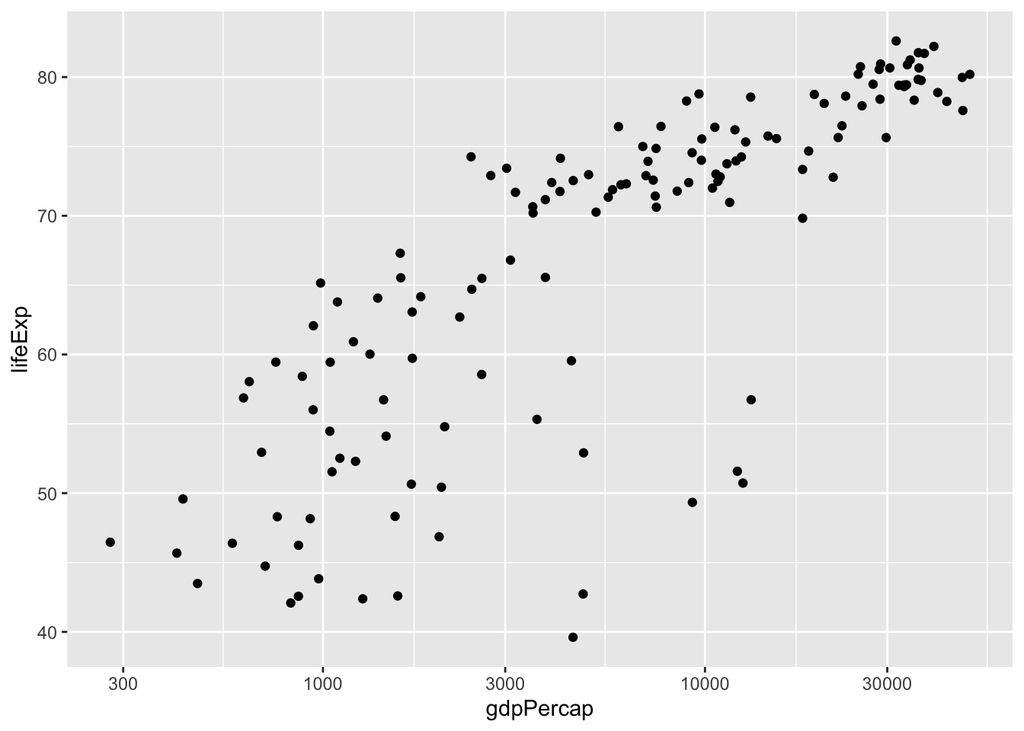

```r
gapminder |>
  filter(year == 2007) |>
  ggplot(aes(x = gdpPercap, y = lifeExp)) +
  geom_point() +
  scale_x_log10()
```

## 6.18 Using more: colour and size

Let’s see more than in just two dimensions! - `aes()` FTW!

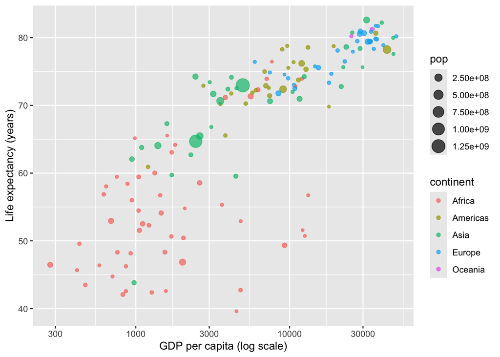

```r
gapminder |>
  filter(year == 2007) |>
  ggplot(aes(x = gdpPercap, y = lifeExp,
             colour = continent, size = pop)) +
  geom_point(alpha = 0.7) +
  scale_x_log10() +
  labs(x = "GDP per capita (log scale)", y = "Life expectancy (years)")
```